# Effects of Transmission Type on Miles per Gallon

Toby Popenfoose

June 20, 2015

### Exploratory Data Analysis:

There were no missing values found.

For EDA I used the str, summary, cor and table functions. See the roughDraft report on github for the particulars. The roughDraft also has the pairs plot of all variables. See Figure 1.

It appears that two variables, am and vs, do not make sense as numeric. I will transform am and vs to factors so the modeling functions will behave better.

```r
mtcars$am <- factor(mtcars$am)
mtcars$vs <- factor(mtcars$vs)
```

### Simple Linear Model:

A naive starting point would be to just do a simple linear regression of just the independent variable am to predict mpg. After doing a simple linear model with just ‘am’ for the predictor, only 36% of the variation is explained by the model suggesting there are other confounder variables to be accounted for.

```r
fit1 <- lm(mpg ~ am, mtcars)
summary(fit1)$r.squared
```

```
## [1] 0.3598
```

### Multivariate Linear Model:

With 10 possible predictor variables there are 2^10= 1,024 different models. To save time, I used stepFit and regsubsets from the leaps package for variable selection using AIC in stepFit and BIC in leaps. See Figure 2 for graphs of the results. Based on the multiple models both methods tested, I have chose to use additional variables of weight and quarter mile time. Using transmission type, weight and quarter mile time explains 85% of the variance.

```r
finalFit <- lm(mpg ~ am + wt + qsec, data=mtcars)
summary(finalFit)$r.squared
```

```
## [1] 0.8497
```

```r
tidy(finalFit, conf.int=TRUE)
```

```
##          term estimate std.error statistic     p.value conf.low conf.high
## 1 (Intercept)    9.618    6.9596     1.382 0.177915165 -4.63830    23.874
## 2         am1    2.936    1.4109     2.081 0.046715510  0.04573     5.826
## 3          wt   -3.917    0.7112    -5.507 0.000006953 -5.37333    -2.460
## 4        qsec    1.226    0.2887     4.247 0.000216174  0.63457     1.817
```

### Diagnostics and Inference:

The residual plots in Figure 3 show there is little heteroscadicity, they are mostly normal, there does not appear to be any significant outliers and there does not appear to be any data points with high influence or high leverage.

```r
anova(fit1, finalFit)
```

```
## Analysis of Variance Table
##
## Model 1: mpg ~ am
## Model 2: mpg ~ am + wt + qsec
##   Res.Df RSS Df Sum of Sq    F       Pr(>F)
## 1     30 721
## 2     28 169  2       552 45.6 0.0000000016
```

The results of the anova are statistically significant at the 95% level and suggests that the multivariable model is better by looking at the residual sum of squares.

```r
vif(finalFit)
```

```
##    am    wt  qsec
## 2.541 2.483 1.364
```

The variance inflation factor suggests there is only moderate correlation between the variables selected which suggests there is not a large amount of collinearity between the variables.

```r
PRESS(fit1)
```

```
## [1] 830.3
```

```r
PRESS(finalFit)
```

```
## [1] 231.3
```

The PRESS statistic is less for the multivariable linear model which suggest is has higher predictive ability due to less predictive error than the simple linear model.

### Appendix:

Figure 1. Ggpairs Plot of Selected mtcars Variables.

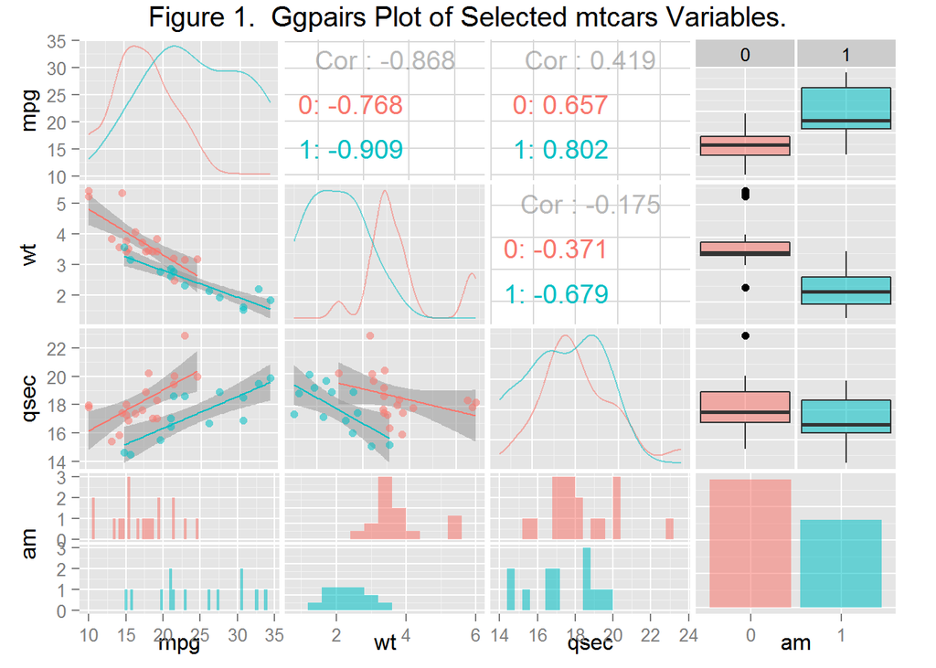

```r
ggpairs(mtcars[ ,c(1,6,7,9)], lower=list(continuous="smooth"), colour="am", alpha=0.4,
        params = c(binwidth=.4), title="Figure 1.  Ggpairs Plot of Selected mtcars Variables.")
```

Figure 2. Multivariate Variable Selection.

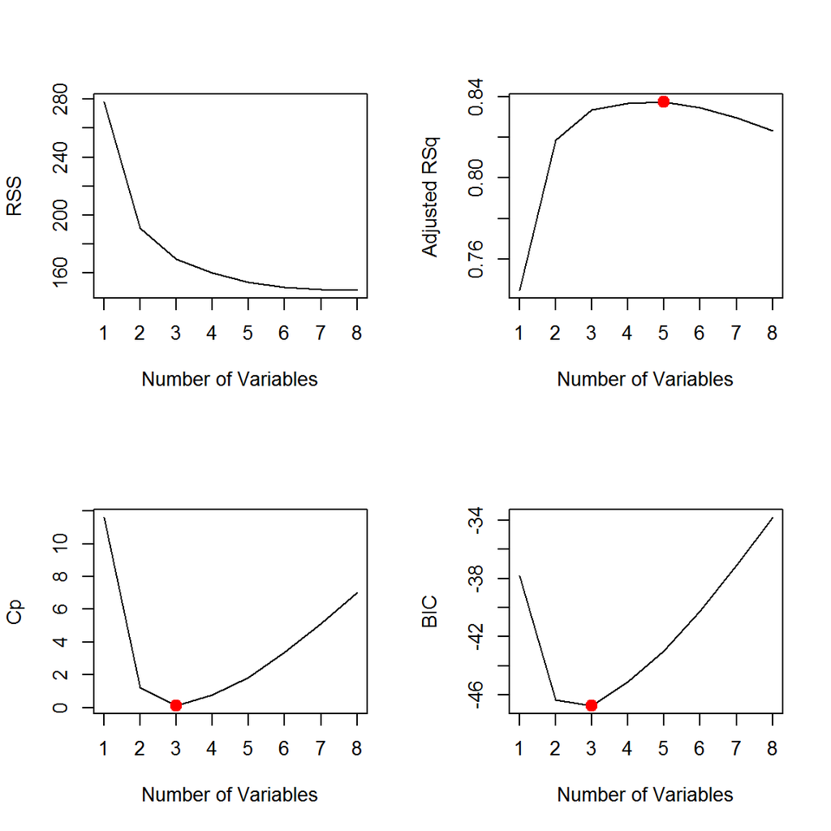

```r
par(mfrow=c(2,2))
plot(leapsSummary$rss, xlab="Number of Variables", ylab="RSS", type="l")
plot(leapsSummary$adjr2, xlab="Number of Variables", ylab="Adjusted RSq", type="l")
points(which.max(leapsSummary$adjr2),
       leapsSummary$adjr2[which.max(leapsSummary$adjr2)], col="red", cex=2, pch=20)
plot(leapsSummary$cp,xlab="Number of Variables", ylab="Cp", type="l")
points(which.min(leapsSummary$cp), leapsSummary$cp[which.min(leapsSummary$cp)],
       col="red", cex=2, pch=20)
plot(leapsSummary$bic, xlab="Number of Variables", ylab="BIC", type="l")
points(which.min(leapsSummary$bic), leapsSummary$bic[which.min(leapsSummary$bic)],
       col="red", cex=2, pch=20)
```

Figure 3. Residuals and Diagnostics Plots for Final Multivariable Linear Model.

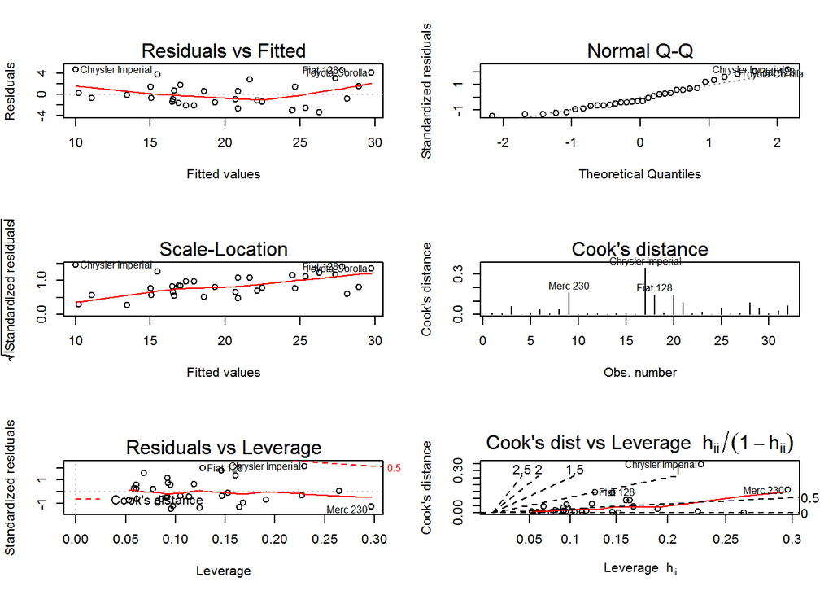

```r
par(mfrow=c(3,2)); plot(finalFit, which=1:6)
```